# American Community Survey 5-year Estimates, Commute Data and Map Examples

Jessica Klein, U.S. Census Bureau

2026-06-10

Mapping Commute Patterns with American Community Survey (ACS) 5-year Estimates Data; using data and geography to reveal commuting structure.

We will demonstrate how ACS data can be transformed into meaningful geographic stories using popular R packages.

Why use maps? Traditional charts summarize data, turning this data into maps reveal spatial patterns and relationships.

Core packages used:

- [tidycensus](https://walker-data.com/tidycensus/) -> ACS API access
- tigris -> Census shapefiles
- [ggplot2](https://ggplot2.tidyverse.org/) -> static thematic maps
- [mapview](https://r-spatial.github.io/mapview/) -> interactive web maps

Start with the 00_setup.R file to install necessary packages and your Census API key

1. Load your necessary packages

```r
# For Census data
library(tidycensus)   # ACS, Decennial
library(censusapi)    # All other Census datasets
# For Census shapefiles
library(tigris)
# For working with the data and visualization, tidyverse packages
library(dplyr)
library(tidyr)
library(ggplot2)
# Spatial data support
library(sf)
# For interactive maps
library(mapview)
library(leaflet)
# For map/visual formatting and composition
library(patchwork)
# For number formatting helpers
library(scales)

# Disable scientific notation
options(scipen = 999)
```

2. Create a visualization output folder for our created visualizations, this is optional.

```r
if (!dir.exists("mapping_visualizations")) {
    dir.create("mapping_visualizations")
}
```

3. Set our tigris settings to cache our Shapefiles locally for faster repeated loading. This helps us conserve space for repeatable processes, but pay attention to space.

```r
options(tigris_use_cache = TRUE)

# Return sf objects
options(tigris_class = "sf")
```

4. Create a list of our ACS Variables for our mapping exercise. We will look at ACS table: [B08303 = Travel Time to Work](https://data.census.gov/table?q=B08303). We will focus on longer commute categories. Our universe is Workers 16 years and over who did not work from home.

```r
acs_vars <- c(
    total_workers   = "B08303_001",
    commute_30_34   = "B08303_008",
    commute_35_39   = "B08303_009",
    commute_40_44   = "B08303_010",
    commute_45_59   = "B08303_011",
    commute_60_89   = "B08303_012",
    commute_90_plus = "B08303_013")
```

5. Retrieve our ACS data from the API using the tidycensus function get_acs(). We will also create a commute intensity score for our visuals.

```r
commute_acs <- get_acs(
    geography = "county",
    variables = acs_vars,
    year = 2024,
    survey = "acs5",      # acs5 is the default
    output = "wide",
    show_call = TRUE) %>%
    mutate(
        # COMMUTE INTENSITY INDEX: Approximate weighted commute burden score,
        # only to be used for demonstration purposes.
        # Larger values indicate counties with more workers
        # experiencing long commute times.
        commute_index =
            (commute_30_34E * 22 +
             commute_35_39E * 32 +
             commute_40_44E * 42 +
             commute_45_59E * 52 +
             commute_60_89E * 75 +
             commute_90_plusE * 100) / total_workersE)

# Place-level ACS data for the U.S. Population

pop_data <- get_acs(
    geography = "place",
    variables = "B01003_001",  # Total population
    year = 2024,
    survey = "acs5",           # acs5 is the default
    show_call = TRUE) %>%
    select(GEOID, population = estimate)
```

We now have our county-level ACS commute data, including estimates used to calculate the long commute index.

```r
print(head(commute_acs, 10))
```

```
## # A tibble: 10 × 17
##    GEOID NAME        total_workersE total_workersM commute_30_34E commute_30_34M
##    <chr> <chr>                <dbl>          <dbl>          <dbl>          <dbl>
##  1 01001 Autauga Co…          25234            906           5097            636
##  2 01003 Baldwin Co…          99432           2168          15054           1644
##  3 01005 Barbour Co…           7916            479            934            206
##  4 01007 Bibb Count…           7565            491            950            188
##  5 01009 Blount Cou…          23928            788           3553            516
##  6 01011 Bullock Co…           3037            377            289            166
##  7 01013 Butler Cou…           6736            365            915            206
##  8 01015 Calhoun Co…          46027           1301           6269            610
##  9 01017 Chambers C…          13460            570           2250            401
## 10 01019 Cherokee C…           9396            427            869            174
## # ℹ 11 more variables: commute_35_39E <dbl>, commute_35_39M <dbl>,
## #   commute_40_44E <dbl>, commute_40_44M <dbl>, commute_45_59E <dbl>,
## #   commute_45_59M <dbl>, commute_60_89E <dbl>, commute_60_89M <dbl>,
## #   commute_90_plusE <dbl>, commute_90_plusM <dbl>, commute_index <dbl>
```

6. Retrieve our Shapefiles from the [Census TIGER/Line Shapefiles site](https://www.census.gov/geographies/mapping-files/time-series/geo/tiger-line-file.html). We will retrieve Shapefiles at the state, county, and place level for mapping. We will also create locations for major city centers and state capitals.

```r
# U.S. counties, shifted geometry

counties_sf <- counties(
    cb = TRUE,
    year = 2024) %>%
    filter(STUSPS %in% c("AK", "HI", "PR", state.abb)) %>%
    shift_geometry()  # used to reposition & rescale Alaska, Hawaii, and Puerto Rico


# U.S. states, shifted geometry

states_sf <- states(
    cb = TRUE,
    year = 2024) %>%
    filter(STUSPS %in% c("AK", "HI", "PR", state.abb)) %>%
    shift_geometry()


# U.S places

places_sf <- places(
    cb = TRUE,
    year = 2024) %>%
    filter(STUSPS %in% c("AK", "HI", "PR", state.abb)) %>%
    shift_geometry() %>%
    mutate(area_sqkm = as.numeric(st_area(geometry)) / 1e6) %>%
    mutate(STUSPS_FIPS = substr(GEOID, 1, 2))  # first two digits of GEOID = state FIPS


# U.S Capitals

state_caps <- tibble::tribble(
    ~state, ~capital,
    "AL", "Montgomery",
    "AK", "Juneau",
    "AZ", "Phoenix",
    "AR", "Little Rock",
    "CA", "Sacramento",
    "CO", "Denver",
    "CT", "Hartford",
    "DE", "Dover",
    "FL", "Tallahassee",
    "GA", "Atlanta",
    "HI", "Honolulu",  # Note, won't be mapped, this is not a Census Place
    "ID", "Boise City",
    "IL", "Springfield",
    "IN", "Indianapolis city (balance)",
    "IA", "Des Moines",
    "KS", "Topeka",
    "KY", "Frankfort",
    "LA", "Baton Rouge",
    "ME", "Augusta",
    "MD", "Annapolis",
    "MA", "Boston",
    "MI", "Lansing",
    "MN", "St. Paul",
    "MS", "Jackson",
    "MO", "Jefferson City",
    "MT", "Helena",
    "NE", "Lincoln",
    "NV", "Carson City",
    "NH", "Concord",
    "NJ", "Trenton",
    "NM", "Santa Fe",
    "NY", "Albany",
    "NC", "Raleigh",
    "ND", "Bismarck",
    "OH", "Columbus",
    "OK", "Oklahoma City",
    "OR", "Salem",
    "PA", "Harrisburg",
    "RI", "Providence",
    "SC", "Columbia",
    "SD", "Pierre",
    "TN", "Nashville-Davidson metropolitan government (balance)",
    "TX", "Austin",
    "UT", "Salt Lake City",
    "VT", "Montpelier",
    "VA", "Richmond",
    "WA", "Olympia",
    "WV", "Charleston",
    "WI", "Madison",
    "WY", "Cheyenne",
    "DC", "Washington")

state_capitals_sf <- places_sf %>%
    inner_join(state_caps, by = c("STUSPS" = "state", "NAME" = "capital"))


# U.S city centers

city_points <- places_sf %>%
    st_centroid() %>%
    filter(PLACEFP != "99999") %>%  # removes non-places
    left_join(pop_data, by = "GEOID")

major_cities <- city_points |>
    filter(STUSPS %in% state.abb | STUSPS == "DC") |>
    filter(AWATER < ALAND) %>%       # remove water-only features
    mutate(density = population / area_sqkm) %>%
    filter(density > 3000)
```

We now have the county boundary geometries needed to map our commute estimates.

```r
print(head(counties_sf, 10))
```

```
## Simple feature collection with 10 features and 12 fields
## Geometry type: MULTIPOLYGON
## Dimension:     XY
## Bounding box:  xmin: -1678739 ymin: -671345.7 xmax: 1796564 ymax: 355366.1
## Projected CRS: USA_Contiguous_Albers_Equal_Area_Conic
##    STATEFP COUNTYFP COUNTYNS        GEOIDFQ GEOID      NAME         NAMELSAD
## 1       01      069 00161560 0500000US01069 01069   Houston   Houston County
## 2       01      023 00161537 0500000US01023 01023   Choctaw   Choctaw County
## 3       01      113 00161583 0500000US01113 01113   Russell   Russell County
## 4       10      005 00217269 0500000US10005 10005    Sussex    Sussex County
## 5       01      071 00161561 0500000US01071 01071   Jackson   Jackson County
## 6       01      089 00161570 0500000US01089 01089   Madison   Madison County
## 7       04      015 00025445 0500000US04015 04015    Mohave    Mohave County
## 8       05      017 00069160 0500000US05017 05017    Chicot    Chicot County
## 9       05      121 00069178 0500000US05121 05121  Randolph  Randolph County
## 10      05      073 00066864 0500000US05073 05073 Lafayette Lafayette County
##    STUSPS STATE_NAME LSAD       ALAND    AWATER                       geometry
## 1      AL    Alabama   06  1501742250   4795418 MULTIPOLYGON (((975268 -651...
## 2      AL    Alabama   06  2365900084  19114321 MULTIPOLYGON (((708032 -598...
## 3      AL    Alabama   06  1660653961  15562947 MULTIPOLYGON (((987614.3 -5...
## 4      DE   Delaware   06  2424590442 674129051 MULTIPOLYGON (((1730706 334...
## 5      AL    Alabama   06  2792044612 126334711 MULTIPOLYGON (((895011.4 -2...
## 6      AL    Alabama   06  2076166271  28756353 MULTIPOLYGON (((837075.1 -2...
## 7      AZ    Arizona   06 34530024143 333399390 MULTIPOLYGON (((-1662580 65...
## 8      AR   Arkansas   06  1649764401 140413175 MULTIPOLYGON (((420519.4 -4...
## 9      AR   Arkansas   06  1688445994  10370823 MULTIPOLYGON (((407497 -102...
## 10     AR   Arkansas   06  1371327391  43028604 MULTIPOLYGON (((198166.5 -4...
```

7. Join our ACS data + Geography so we can link our data and coordinates.

```r
county_map <- counties_sf %>%
    left_join(commute_acs, by = "GEOID")
```

Our ACS data and county geographic boundaries are now joined into one spatial dataset ready for mapping.

```r
cat("We now have geometry available for mapping:\n\n")
```

```
## We now have geometry available for mapping:
```

```r
head(county_map %>%
  select(STATE_NAME, NAMELSAD, commute_index, geometry), 10)
```

```
## Simple feature collection with 10 features and 3 fields
## Geometry type: MULTIPOLYGON
## Dimension:     XY
## Bounding box:  xmin: -1678739 ymin: -671345.7 xmax: 1796564 ymax: 355366.1
## Projected CRS: USA_Contiguous_Albers_Equal_Area_Conic
##    STATE_NAME         NAMELSAD commute_index                       geometry
## 1     Alabama   Houston County     10.747507 MULTIPOLYGON (((975268 -651...
## 2     Alabama   Choctaw County     28.576447 MULTIPOLYGON (((708032 -598...
## 3     Alabama   Russell County     15.560755 MULTIPOLYGON (((987614.3 -5...
## 4    Delaware    Sussex County     17.399067 MULTIPOLYGON (((1730706 334...
## 5     Alabama   Jackson County     19.317906 MULTIPOLYGON (((895011.4 -2...
## 6     Alabama   Madison County      9.829462 MULTIPOLYGON (((837075.1 -2...
## 7     Arizona    Mohave County      9.526120 MULTIPOLYGON (((-1662580 65...
## 8    Arkansas    Chicot County     10.353470 MULTIPOLYGON (((420519.4 -4...
## 9    Arkansas  Randolph County     14.111000 MULTIPOLYGON (((407497 -102...
## 10   Arkansas Lafayette County     23.999050 MULTIPOLYGON (((198166.5 -4...
```

```r
cat("\n\n")
```

```r
cat("Full list of columns available:\n\n")
```

```
## Full list of columns available:
```

```r
colnames(county_map)
```

```
##  [1] "STATEFP"          "COUNTYFP"         "COUNTYNS"         "GEOIDFQ"
##  [5] "GEOID"            "NAME.x"           "NAMELSAD"         "STUSPS"
##  [9] "STATE_NAME"       "LSAD"             "ALAND"            "AWATER"
## [13] "NAME.y"           "total_workersE"   "total_workersM"   "commute_30_34E"
## [17] "commute_30_34M"   "commute_35_39E"   "commute_35_39M"   "commute_40_44E"
## [21] "commute_40_44M"   "commute_45_59E"   "commute_45_59M"   "commute_60_89E"
## [25] "commute_60_89M"   "commute_90_plusE" "commute_90_plusM" "commute_index"
## [29] "geometry"
```

8. Create a Census Color Palette list.

```r
# Census-style blue palette

census_blues <- c(
    "#D5E1EF",  #very light blue tint
    "#A9C3DF",  #light desaturated blue
    "#7DA5CF",  #medium-light blue
    "#4F84BA",  #midtone complementary blue
    "#205493",  #official Census Blue
    "#0E3B6F",  #darkened Census Blue
    "#062644")  #very dark navy anchor
```

Now, lets start mapping!

### Map 1: Mapping Long Commute Patterns Across U.S. Counties

**Goal**: Using the ACS commute data, joined to county boundaries and city reference layers, and create a thematic map showing counties with higher concentrations of long commutes.

```r
national_map <- ggplot(county_map) +
    geom_sf(aes(fill = commute_index),
            color = NA) +
    geom_sf(data = state_capitals_sf,
            color = "darkred",
            shape = 8,
            size = 1,
            alpha = 0.7) +
    geom_sf(data = major_cities,
            color = "darkorange",
            shape = 18,
            size = 1,
            alpha = 0.7) +
    scale_fill_gradientn(colors = census_blues,
                         name = "Commute Index Calculation",
                         labels = scales::label_number(accuracy = 1)) +
    labs(title = "Workers with Commutes of 30 Minutes or Longer Across U.S. Counties",
         subtitle = "Red = State Capitals | Orange = Major Cities",
         caption = "Source: American Community Survey 5-year Estimates 2024") +
    coord_sf(expand = FALSE) +
    theme_void() +
    theme(plot.title = element_text(hjust = 0.5, face = "bold", margin = margin(b = 5)),
          plot.title.position = "panel",
          plot.subtitle = element_text(hjust = 0.5, margin = margin(b = 4)),
          legend.position = "bottom",
          legend.direction = "horizontal",
          legend.title = element_text(size = 9, face = "bold"),
          legend.text = element_text(size = 8),
          plot.margin = margin(t = 5, r = 5, b = 5, l = 5)) +
    guides(fill = guide_colorbar(title.position = "top",
                                 barwidth = 14,
                                 barheight = 0.6))
```

**Workflow**: ACS Data → Create Commute Index → County Shapefile → State Capitals → Major Cities → Join Layers → Map

This first example demonstrates the workflow pattern we will use throughout the demonstration. We first retrieve ACS data, next obtain the relevant geographic boundary, then join them on a shared linking column, and finally create a map with the resulting data. For the following examples, we are not mapping just one published Census variable, instead we combined multiple commute categories to create a custom measure focused on mapping areas with longer commutes.

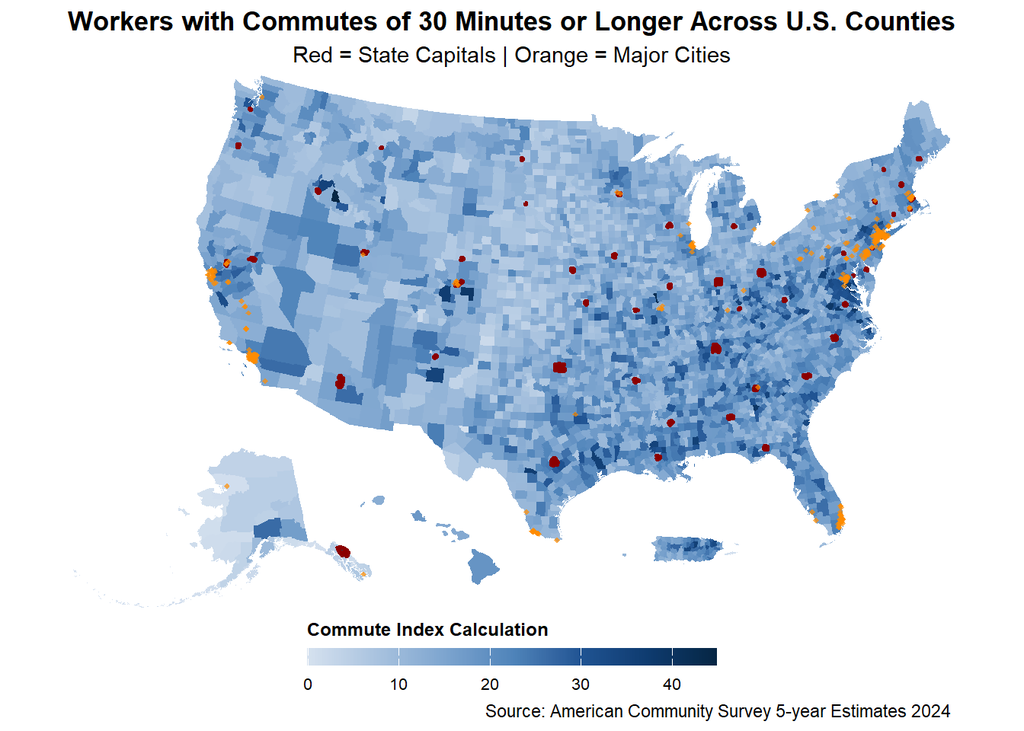

```r
print(national_map)
```

### Map 2: Exploring Commute Patterns in the Washington, DC Area

**Goal**: Filter geographic data to a smaller area and view regional commuting patterns using county-level ACS estimates.

```r
# Filter our county shapefile to only the states we want to visualize

dc_counties <- county_map %>%
    filter(STATEFP %in% c("11", # DC
                          "24", # Maryland
                          "51", # Virginia
                          "10", # Delaware
                          "54", # West Virginia
                          "42")) # Pennsylvania

cat("We now have all counties in select states:\n\n")
```

```
## We now have all counties in select states:
```

```r
head(dc_counties %>%
  select(STATE_NAME, NAMELSAD, commute_index, geometry), 10)
```

```
## Simple feature collection with 10 features and 3 fields
## Geometry type: MULTIPOLYGON
## Dimension:     XY
## Bounding box:  xmin: 1607677 ymin: 197916.4 xmax: 1796564 ymax: 579415.1
## Projected CRS: USA_Contiguous_Albers_Equal_Area_Conic
##      STATE_NAME              NAMELSAD commute_index
## 1      Delaware         Sussex County      17.39907
## 2      Delaware     New Castle County      14.34201
## 3      Maryland      Baltimore County      18.44006
## 4      Maryland     Dorchester County      17.84331
## 5      Maryland        Charles County      37.92518
## 6      Maryland          Cecil County      20.72040
## 7  Pennsylvania      Lancaster County      13.38515
## 8  Pennsylvania    Northampton County      16.58814
## 9      Virginia Northumberland County      23.07992
## 10     Virginia   Westmoreland County      36.69088
##                          geometry
## 1  MULTIPOLYGON (((1730706 334...
## 2  MULTIPOLYGON (((1727469 411...
## 3  MULTIPOLYGON (((1668826 376...
## 4  MULTIPOLYGON (((1718217 251...
## 5  MULTIPOLYGON (((1607677 269...
## 6  MULTIPOLYGON (((1667127 422...
## 7  MULTIPOLYGON (((1617511 458...
## 8  MULTIPOLYGON (((1693625 550...
## 9  MULTIPOLYGON (((1673513 223...
## 10 MULTIPOLYGON (((1632445 237...
```

```r
dc_map <- ggplot(dc_counties) +
    geom_sf(aes(fill = commute_index),
            color = "white",
            linewidth = 0.2) +
    scale_fill_gradientn(colors = census_blues,
                         name = "Commute Index Calculation",
                         labels = scales::label_number(accuracy = 1)) +
    coord_sf(expand = FALSE) +
    labs(title = "County-level Commute Patterns Across the Washington DC Metropolitan Area",
         caption = "Source: American Community Survey 5-year Estimates 2024") +
    theme_void() +
    theme(plot.title = element_text(hjust = 0.5, face = "bold", margin = margin(b = 5)),
          plot.title.position = "panel",
          legend.position = "bottom",
          legend.direction = "horizontal",
          legend.title = element_text(size = 9, face = "bold"),
          legend.text = element_text(size = 8),
          plot.margin = margin(t = 5, r = 5, b = 5, l = 5)) +
    guides(fill = guide_colorbar(title.position = "top",
                                 barwidth = 14,
                                 barheight = 0.6))
```

**Workflow**: ACS Data → Create Commute Index → County Shapefile → Filter to DC/MD/VA/DE/WV/PA → Map

This example demonstrates how geographic filtering can focus a map on a specific region while preserving county-level detail.

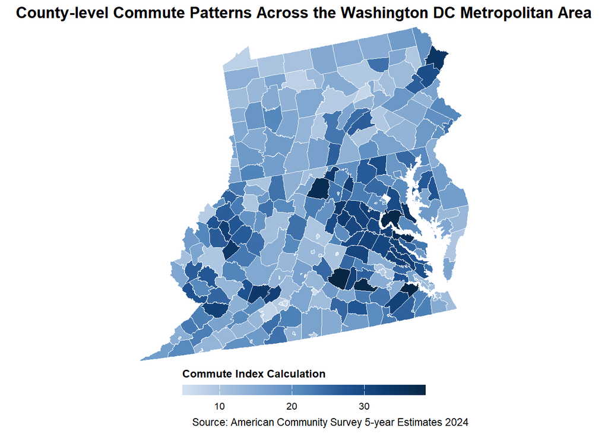

```r
dc_map
```

### Map 3: Calculating and Mapping Average Commute Time by State

**Goal**: Use ACS commute distributions to calculate a weighted mean commute time and visualize the results at the state level.

```r
# Get state level commute table

commute_time <- get_acs(geography = "state",
                        table = "B08303",
                        year = 2024,
                        survey = "acs5",
                        output = "wide",
                        show_call = TRUE)

cat("Full list of columns, we now have all commute variables:\n\n")
```

```
## Full list of columns, we now have all commute variables:
```

```r
colnames(commute_time)
```

```
##  [1] "GEOID"       "NAME"        "B08303_001E" "B08303_001M" "B08303_002E"
##  [6] "B08303_002M" "B08303_003E" "B08303_003M" "B08303_004E" "B08303_004M"
## [11] "B08303_005E" "B08303_005M" "B08303_006E" "B08303_006M" "B08303_007E"
## [16] "B08303_007M" "B08303_008E" "B08303_008M" "B08303_009E" "B08303_009M"
## [21] "B08303_010E" "B08303_010M" "B08303_011E" "B08303_011M" "B08303_012E"
## [26] "B08303_012M" "B08303_013E" "B08303_013M"
```

```r
# Define midpoints for each commute variable

midpoints <- c(
    "B08303_002E" = 2.5,
    "B08303_003E" = 7,
    "B08303_004E" = 12,
    "B08303_005E" = 17,
    "B08303_006E" = 22,
    "B08303_007E" = 27,
    "B08303_008E" = 32,
    "B08303_009E" = 37,
    "B08303_010E" = 42,
    "B08303_011E" = 52.5,
    "B08303_012E" = 75,
    "B08303_013E" = 95)


# Compute weighted mean commute time

commute_weighted <- commute_time %>%
    rowwise() %>%
    mutate(
        avg_commute = sum(c_across(names(midpoints)) * midpoints) /
            B08303_001E) %>%
    ungroup() %>%
    select(GEOID, NAME, avg_commute)


# Get state level shapefile and shift geometry

states_sf <- states(cb = TRUE,
                    year = 2024) %>%
    shift_geometry()

# Join our data and shapefile

commute_map <- states_sf %>%
    left_join(commute_weighted, by = "GEOID")

cat("\n\n")
```

```r
cat("We now have data and geography linked:\n\n")
```

```
## We now have data and geography linked:
```

```r
head(commute_map %>%
  select(NAME.x, avg_commute, geometry), 10)
```

```
## Simple feature collection with 10 features and 2 fields
## Geometry type: MULTIPOLYGON
## Dimension:     XY
## Bounding box:  xmin: -2356114 ymin: -782290.7 xmax: 1781848 ymax: 970427.9
## Projected CRS: USA_Contiguous_Albers_Equal_Area_Conic
##          NAME.x avg_commute                       geometry
## 1    New Mexico    25.00946 MULTIPOLYGON (((-1231344 -5...
## 2  South Dakota    19.05659 MULTIPOLYGON (((-633765.6 8...
## 3    California    30.75098 MULTIPOLYGON (((-2066923 -2...
## 4      Kentucky    25.52380 MULTIPOLYGON (((584560 -886...
## 5       Alabama    27.34241 MULTIPOLYGON (((760323.7 -7...
## 6       Georgia    30.42037 MULTIPOLYGON (((1390722 -58...
## 7      Arkansas    24.10384 MULTIPOLYGON (((122656.3 -1...
## 8  Pennsylvania    28.13409 MULTIPOLYGON (((1287712 486...
## 9      Missouri    25.16283 MULTIPOLYGON (((19008.51 34...
## 10     Colorado    27.04786 MULTIPOLYGON (((-1123223 20...
```

```r
# Create the state level commute map using the estimated mean commute time calculation

state_map <- ggplot(commute_map) +
    geom_sf(aes(fill = avg_commute),
            color = "white",
            linewidth = 0.2) +
    scale_fill_gradientn(colors = census_blues,
                         name = "Average Minutes") +
    labs(title = "Weighted Average Commute Times Across States",
        caption = "Source: American Community Survey 5-year Estimates 2024") +
    coord_sf(xlim = c(-2500000, 2500000), ylim = c(-2200000, 1900000), expand = FALSE) +
    theme_void() +
    theme(plot.title = element_text(hjust = 0.5, face = "bold", margin = margin(b = 5)),
          plot.title.position = "panel",
          plot.subtitle = element_text(hjust = 0.5, margin = margin(b = 4)),
          legend.position = "bottom",
          legend.direction = "horizontal",
          legend.title = element_text(size = 9, face = "bold"),
          legend.text = element_text(size = 8),
          plot.margin = margin(t = 5, r = 5, b = 5, l = 5)) +
    guides(fill = guide_colorbar(title.position = "top",
                                 barwidth = 14,
                                 barheight = 0.6))
```

**Workflow**: ACS Commute Variables → Create Midpoints → Calculate Weighted Mean → Join State Boundaries → Map

This example demonstrates how ACS category distributions can be transformed into a continuous measure through weighted averages, enabling more advanced analyses and visualizations.

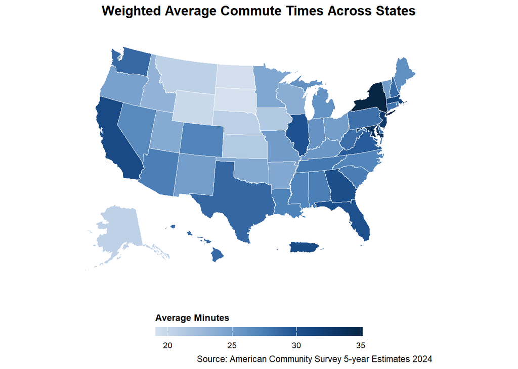

```r
state_map
```